# Fine-Tuned MobileNetV2

## Fine-Tuned MobileNet With TensorFlow's Keras API for a data set of [sign language digits](https://github.com/ardamavi/Sign-Language-Digits-Dataset)

- By: [Ismail Ouahbi](https://www.linkedin.com/in/ismail-ouahbi-071145207/) (06/07/2023)

### Introduction

`MobileNetV2` is a popular deep learning model that was introduced `by Google in 2018` as an improvement over its predecessor, `MobileNetV1`. It is `designed specifically for mobile and embedded devices with limited computational resources`.

The primary goal of MobileNetV2 is to provide a `lightweight and efficient architecture` while still achieving competitive accuracy in various computer vision tasks.

### Why MobileNetV2?

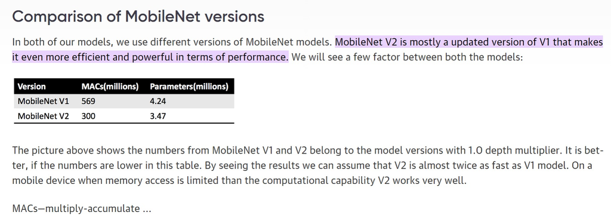

Credit

### Let Us Start!

```python
# import libraries

import numpy as np
import pandas as pd
import matplotlib.pyplot as plt
import os
import random
import matplotlib.pyplot as plt
import matplotlib.image as mpimg
import shutil
import tensorflow as tf
from tensorflow import keras
from keras.preprocessing.image import ImageDataGenerator
from keras.layers.core import Dense

# define the base working directory
BASE_DIR = os.getcwd()

# define data directory

DATA_DIR = os.path.join(BASE_DIR, 'data')

# define paths to the other directories

TRAIN_DIR = os.path.join(DATA_DIR, 'train')
VALIDATION_DIR = os.path.join(DATA_DIR, 'validation')
TEST_DIR = os.path.join(DATA_DIR, 'test')
```

### Details of datasets:

- Image size: 100 x 100 pixels
- Color space: RGB
- Number of classes: 10 (Digits: 0-9)
- Number of participant students: 218
- Number of samples per student: 10

### Data set Preview

```python
# A function to get a random image from each class using the data folder, and show them


def show_nRandom_images(data_dir= DATA_DIR):
    # for each class, grab one random image
    for class_ in os.listdir(DATA_DIR):
        # Get a list of all image files in the folder
        image_files = [f for f in os.listdir(os.path.join(DATA_DIR,class_)) if os.path.isfile(os.path.join(DATA_DIR,class_ ,f))]
        # Select a random image from the list and Display it

        img = mpimg.imread(os.path.join(os.path.join(DATA_DIR,class_ ,random.choice(image_files))))
        plt.imshow(img)
        plt.title('sample from class {}'.format(class_))
#         plt.axis('off')
        plt.show()
```

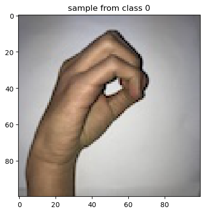

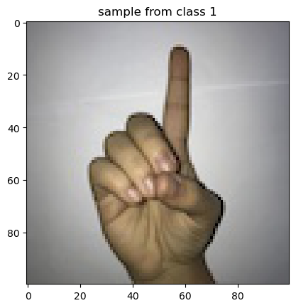

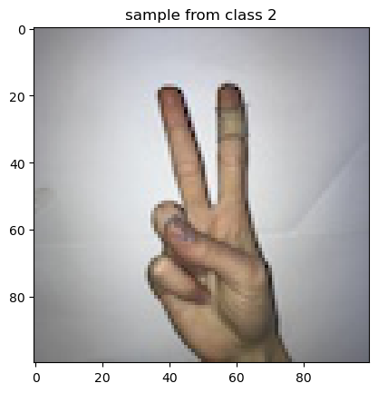

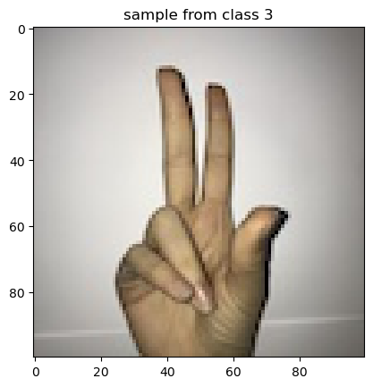

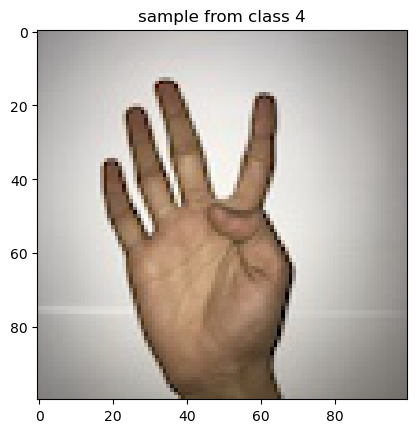

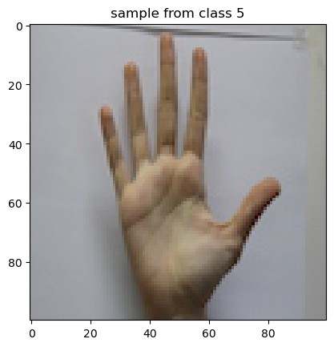

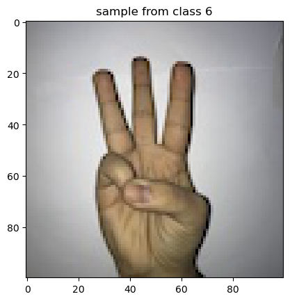

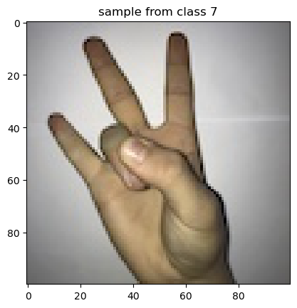

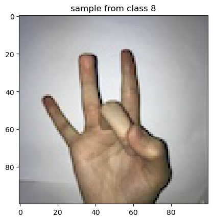

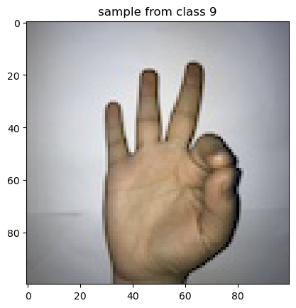

```python
# execute the function
show_nRandom_images()
```

### Statistics about the dataset

```python
#### See number of samples within each class

def get_metadata():
    metadata_df = pd.DataFrame(columns=['class','n_sample'] , index=[])

    for class_ in range(10):
        # Get a list of all image files in the folder
        image_files = [f for f in os.listdir(os.path.join(DATA_DIR,str(class_))) if os.path.isfile(os.path.join(DATA_DIR,str(class_) ,f))]
        metadata_df.loc[metadata_df.shape[0],['class','n_sample']] = [str(class_),len(image_files)]
    return metadata_df
```

```python
# see results
get_metadata()
```

|  | class | n_sample |
| --- | --- | --- |
| 0 | 0 | 205 |
| 1 | 1 | 206 |
| 2 | 2 | 206 |
| 3 | 3 | 206 |
| 4 | 4 | 207 |
| 5 | 5 | 207 |
| 6 | 6 | 207 |
| 7 | 7 | 206 |
| 8 | 8 | 208 |
| 9 | 9 | 204 |

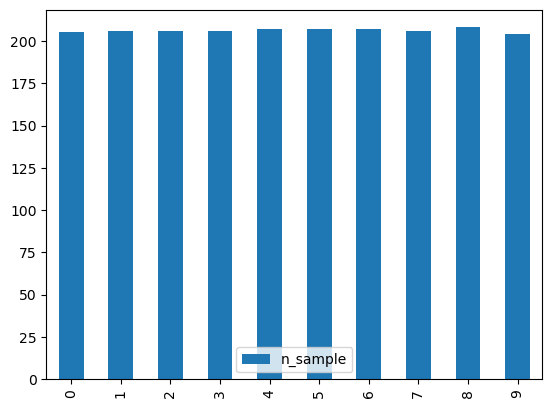

```python
# more details about each class samples
get_metadata().plot.bar()
```

**The data is balanced as expected**

### Organize data into train, validation and test data

#### Our data folder will follow the given structure

data/

- train/

- validation/

(30 samples)

- test/

(5 samples)

```python
# verify that this structure is not here yet
if(os.path.isdir(os.path.join(DATA_DIR,'train')) == False):

    # create three directories (train, val, test)
    os.mkdir(os.path.join(DATA_DIR,'train'))
    os.mkdir(os.path.join(DATA_DIR,'validation'))
    os.mkdir(os.path.join(DATA_DIR,'test'))

    # Organize data to follow a machine learning dataset structure

        # loop through the original data folder
    for class_ in range(10):
        # Get a list of all image files in the folder
        image_files = [f for f in os.listdir(os.path.join(DATA_DIR,str(class_))) if os.path.isfile(os.path.join(DATA_DIR,str(class_) ,f))]

        # for validation

            # create corresponding class_ folder
        os.mkdir(os.path.join(VALIDATION_DIR,str(class_)))
            # take 30 random samples
        validation_set = random.sample(image_files, 30)
            # move them to the validation directory
        for validation_img in validation_set:
            shutil.move(os.path.join(DATA_DIR,str(class_),validation_img), os.path.join(VALIDATION_DIR,str(class_)))

        # for test

        # Refresh the list of all image files in the folder
        image_files = [f for f in os.listdir(os.path.join(DATA_DIR,str(class_))) if os.path.isfile(os.path.join(DATA_DIR,str(class_) ,f))]

            # create corresponding class_ folder
        os.mkdir(os.path.join(TEST_DIR,str(class_)))
            # take 30 random samples
        test_set = random.sample(image_files, 5)
            # move them to the test directory
        for test_img in test_set:
            shutil.move(os.path.join(DATA_DIR,str(class_),test_img), os.path.join(TEST_DIR,str(class_)))

    # for training
        # takes the remaining samples

    for class_ in range(10):

        # Get a list of all image files in the folder
        train_set = [f for f in os.listdir(os.path.join(DATA_DIR,str(class_))) if os.path.isfile(os.path.join(DATA_DIR,str(class_) ,f))]

        # create corresponding class_ folder
        os.mkdir(os.path.join(TRAIN_DIR,str(class_)))

        # move them to the validation directory
        for train_img in train_set:
            shutil.move(os.path.join(DATA_DIR,str(class_),train_img), os.path.join(TRAIN_DIR,str(class_)))


else:
    print('The structure you are trying to create is already here!')
```

### Verify the new distribution of data

```python
# a function to do the job

def get_metadataOfFolder(folder_name, folder_path):
    metadata_df = pd.DataFrame(columns=[folder_name+'_classes','{}_samples'.format(folder_name)] , index=[])

    for class_ in os.listdir(folder_path):
        # Get a list of all image files in the folder
        image_files = [f for f in os.listdir(os.path.join(folder_path,class_)) if os.path.isfile(os.path.join(folder_path, class_ ,f))]
        metadata_df.loc[metadata_df.shape[0],[folder_name+'_classes','{}_samples'.format(folder_name)]] = [str(class_),len(image_files)]
    return metadata_df
```

```python
# for training data
get_metadataOfFolder('train',TRAIN_DIR)
```

|  | train_classes | train_samples |
| --- | --- | --- |
| 0 | 0 | 170 |
| 1 | 1 | 171 |
| 2 | 2 | 171 |
| 3 | 3 | 171 |
| 4 | 4 | 172 |
| 5 | 5 | 172 |
| 6 | 6 | 172 |
| 7 | 7 | 171 |
| 8 | 8 | 173 |
| 9 | 9 | 169 |

```python
# for testing data
get_metadataOfFolder('test',TEST_DIR)
```

|  | test_classes | test_samples |
| --- | --- | --- |
| 0 | 0 | 5 |
| 1 | 1 | 5 |
| 2 | 2 | 5 |
| 3 | 3 | 5 |
| 4 | 4 | 5 |
| 5 | 5 | 5 |
| 6 | 6 | 5 |
| 7 | 7 | 5 |
| 8 | 8 | 5 |
| 9 | 9 | 5 |

```python
# for validation data
get_metadataOfFolder('validation',VALIDATION_DIR)
```

|  | validation_classes | validation_samples |
| --- | --- | --- |
| 0 | 0 | 30 |
| 1 | 1 | 30 |
| 2 | 2 | 30 |
| 3 | 3 | 30 |
| 4 | 4 | 30 |
| 5 | 5 | 30 |
| 6 | 6 | 30 |
| 7 | 7 | 30 |
| 8 | 8 | 30 |
| 9 | 9 | 30 |

### Pre-Process the data

- We will be converting each images to follow the same format MobileNet expects

```python
train_chunks = ImageDataGenerator(preprocessing_function=tf.keras.applications.mobilenet_v2.preprocess_input).flow_from_directory(
    directory=TRAIN_DIR, target_size=(224,224), batch_size=10)

valid_chunks = ImageDataGenerator(preprocessing_function=tf.keras.applications.mobilenet_v2.preprocess_input).flow_from_directory(
    directory=VALIDATION_DIR, target_size=(224,224), batch_size=10)

test_chunks = ImageDataGenerator(preprocessing_function=tf.keras.applications.mobilenet_v2.preprocess_input).flow_from_directory(
    directory=TEST_DIR, target_size=(224,224), batch_size=10, shuffle=False)
```

```
Found 1712 images belonging to 10 classes.
Found 300 images belonging to 10 classes.
Found 50 images belonging to 10 classes.
```

### Modeling part

```python
# Initialize the MobileNetV2 object

mobilenetv2 = tf.keras.applications.MobileNetV2(weights='imagenet', include_top=False, input_shape=(224, 224, 3))
```

**By setting include_top=False, you exclude these dense layers, effectively removing the final classification/regression functionality of the pre-trained model. This allows you to add your own custom top layers suited to your specific task, such as a different number of output classes or a different type of prediction.**

```python
# Discover model architecture

mobilenetv2.summary()
```

```
Model: "mobilenetv2_1.00_224"
__________________________________________________________________________________________________
 Layer (type)                   Output Shape         Param #     Connected to
==================================================================================================
 input_17 (InputLayer)          [(None, 224, 224, 3  0           []
                                )]

 Conv1 (Conv2D)                 (None, 112, 112, 32  864         ['input_17[0][0]']
                                )

 bn_Conv1 (BatchNormalization)  (None, 112, 112, 32  128         ['Conv1[0][0]']
                                )

 Conv1_relu (ReLU)              (None, 112, 112, 32  0           ['bn_Conv1[0][0]']
                                )

 expanded_conv_depthwise (Depth  (None, 112, 112, 32  288        ['Conv1_relu[0][0]']
 wiseConv2D)                    )

 expanded_conv_depthwise_BN (Ba  (None, 112, 112, 32  128        ['expanded_conv_depthwise[0][0]']
 tchNormalization)              )

 expanded_conv_depthwise_relu (  (None, 112, 112, 32  0          ['expanded_conv_depthwise_BN[0][0
 ReLU)                          )                                ]']

 expanded_conv_project (Conv2D)  (None, 112, 112, 16  512        ['expanded_conv_depthwise_relu[0]
                                )                                [0]']

 expanded_conv_project_BN (Batc  (None, 112, 112, 16  64         ['expanded_conv_project[0][0]']
 hNormalization)                )

 block_1_expand (Conv2D)        (None, 112, 112, 96  1536        ['expanded_conv_project_BN[0][0]'
                                )                                ]

 block_1_expand_BN (BatchNormal  (None, 112, 112, 96  384        ['block_1_expand[0][0]']
 ization)                       )

 block_1_expand_relu (ReLU)     (None, 112, 112, 96  0           ['block_1_expand_BN[0][0]']
                                )

```

[output cut: 348 more lines]

```

 block_16_project_BN (BatchNorm  (None, 7, 7, 320)   1280        ['block_16_project[0][0]']
 alization)

 Conv_1 (Conv2D)                (None, 7, 7, 1280)   409600      ['block_16_project_BN[0][0]']

 Conv_1_bn (BatchNormalization)  (None, 7, 7, 1280)  5120        ['Conv_1[0][0]']

 out_relu (ReLU)                (None, 7, 7, 1280)   0           ['Conv_1_bn[0][0]']

==================================================================================================
Total params: 2,257,984
Trainable params: 2,223,872
Non-trainable params: 34,112
__________________________________________________________________________________________________
```

```python
#Freeze the base model layers
mobilenetv2.trainable = False
```

```python
# Create the input tensor
inputs = tf.keras.Input(shape=(224, 224, 3))

# Apply the pre-trained base model to the inputs
x = mobilenetv2(inputs, training=False)

# Add a global average pooling layer
x = tf.keras.layers.GlobalAveragePooling2D()(x)

# Add the output layer with the desired number of classes
outputs = Dense(units=10, activation='softmax')(x)

# Create the final model
model_ = tf.keras.Model(inputs, outputs)
```

```python
# get the new model summary

model_.summary()
```

```
Model: "model_7"
_________________________________________________________________
 Layer (type)                Output Shape              Param #
=================================================================
 input_16 (InputLayer)       [(None, 224, 224, 3)]     0

 mobilenetv2_1.00_224 (Funct  (None, 7, 7, 1280)       2257984
 ional)

 global_average_pooling2d_11  (None, 1280)             0
  (GlobalAveragePooling2D)

 dense_15 (Dense)            (None, 10)                12810

=================================================================
Total params: 2,270,794
Trainable params: 12,810
Non-trainable params: 2,257,984
_________________________________________________________________
```